# Informe M8R2

Esperanza de Vida y GDP PPP en Suramérica (1875-2025)

Gabriel Parada

2025-08-08

# 1 Paquetes

```r
library(knitr)
library(tidyr)
library(plotly)
library(readxl)
library(dplyr)
library(ggplot2)
library(here)
library(sf)
library(ggplot2)
library(plotly)
library(dplyr)
library(readr)
library(DT)
library(kableExtra)
library(gridExtra)
```

# 2 Cargar los datos

```r
df_LA_GDP <- read.csv(here("Datos", "df_LA_GDP.csv"))
```

# 3 Introducción

El presente trabajo investiga el nivel de la **esperanza de vida** desde el año 1875 hasta el 2025 en Suramérica y su relación con el **GDP per cápita (PPP)**.

| GDP.per.cápita.PPP | Esperanza.de.Vida |
| --- | --- |
| Es una medida de la producción económica per cápita de un país, ajustada por las diferencias en el costo de vida y los tipos de cambio entre países. | La esperanza de vida es el número promedio de años que se espera que viva una persona desde su nacimiento, considerando las condiciones de mortalidad de un período específico. |

## 3.1 Sobre los datos

El presente estudio une dos datasets:

1. **Life Expectancy Dataset v14:** Contiene datos sobre la esperanza de vida de todos los países del mundo compilados a partir de múltiples fuentes, principalmente del Instituto de Métricas y Evaluación de la Salud (IHME).
2. **GDP per capita in constant PPP dollars v31(PPP$2021):** Este provee datos históricos sobre el GDP per capita (Producto Interior Bruto per capita en español) PPP para todos los países del mundo.
3. **Notas**: Ambos datasets fueron recopilados por Gapminder, estos tienen datos desde 1800 hasta 2100. Pero para el presente estudio se filtrarán los datos desde **1875 hasta 2025.**

# 4 Estadísticas Descriptivas 1875-2025

| Países | min.Esp.Vida | max.Esp.Vida | med.Esp.Vida | min.GDP | max.GDP | med.GDP |
| --- | --- | --- | --- | --- | --- | --- |
| Argentina | 32.91 | 77.60 | 58.51 | 2910 | 24600 | 11345.30 |
| Bolivia | 27.21 | 73.47 | 44.95 | 1490 | 8530 | 3704.90 |
| Brazil | 25.97 | 77.09 | 48.55 | 973 | 16000 | 5501.89 |
| Chile | 26.85 | 81.39 | 51.68 | 2180 | 26700 | 9023.31 |
| Colombia | 30.26 | 81.37 | 52.94 | 1220 | 15900 | 5320.07 |
| Ecuador | 30.13 | 77.51 | 51.36 | 870 | 11300 | 4490.91 |
| Guyana | 27.43 | 68.26 | 48.42 | 2020 | 72800 | 6028.87 |
| Peru | 28.79 | 81.49 | 49.53 | 870 | 13000 | 4889.18 |
| Uruguay | 30.36 | 78.50 | 55.20 | 3540 | 25900 | 9335.36 |
| Venezuela | 30.73 | 76.18 | 53.20 | 1830 | 21000 | 9357.75 |

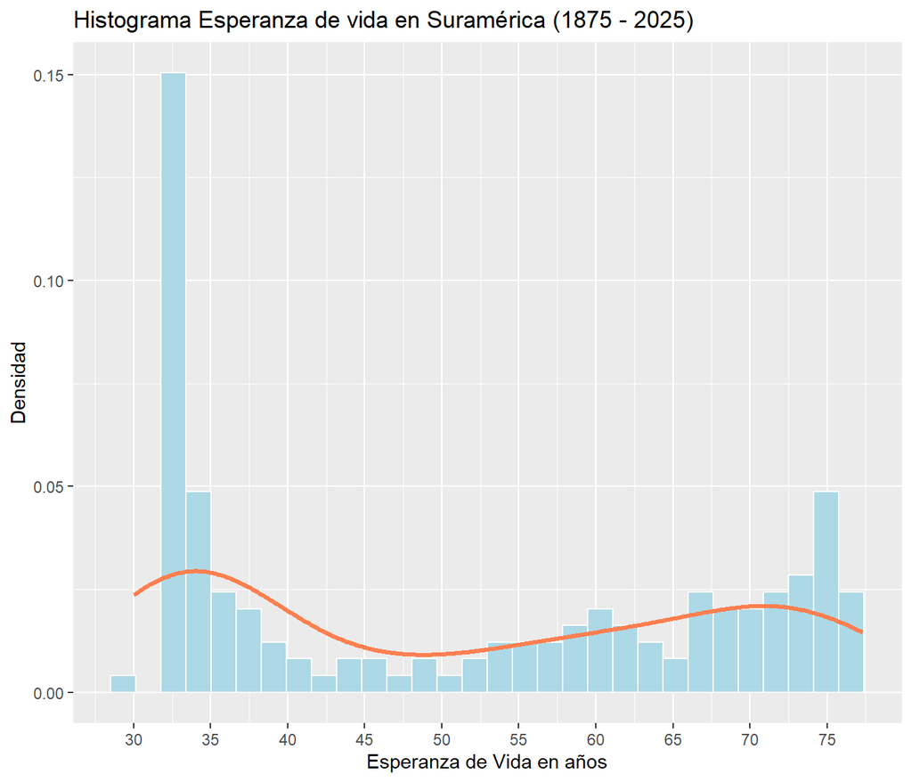

- Al observar la distribución de densidad de la Esperanza de Vida de los países de Suramérica en los últimos 150 años se nota que un tercio de la misma se situa entre los 30 y 37.5 años.
- Luego incrementa rápidamente y se estabiliza un poco entre el rango de 67 a 80 años.

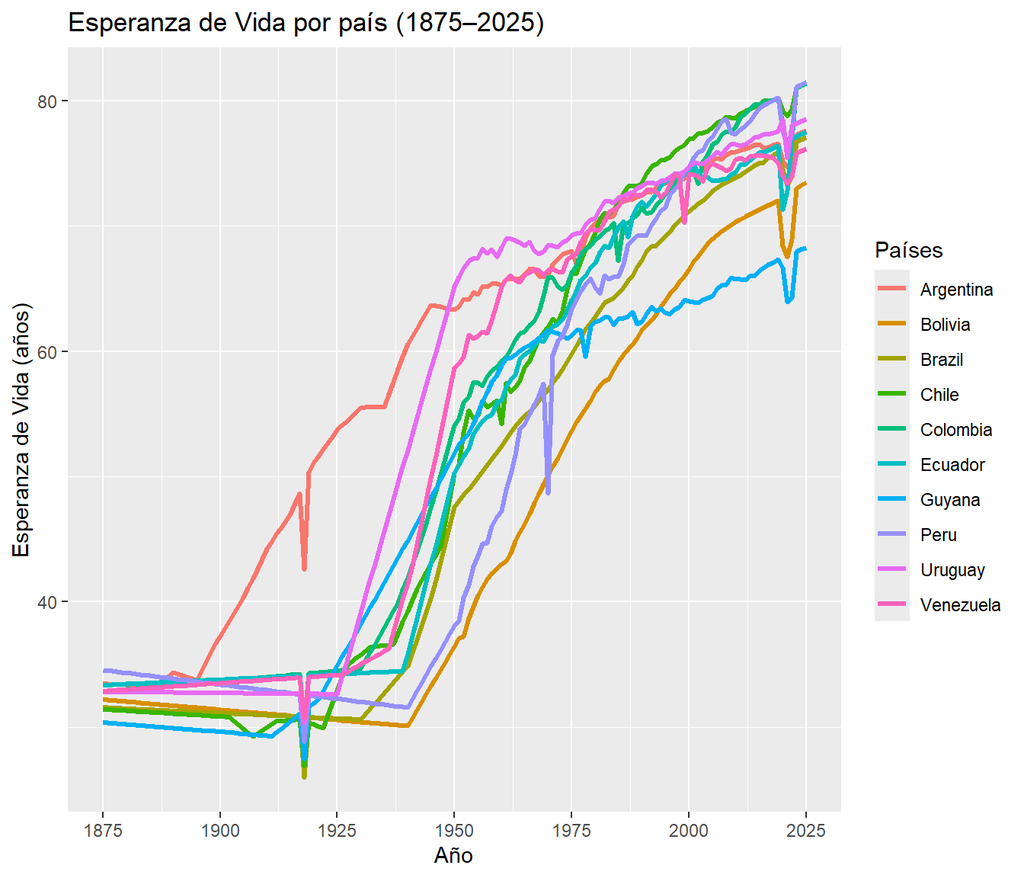

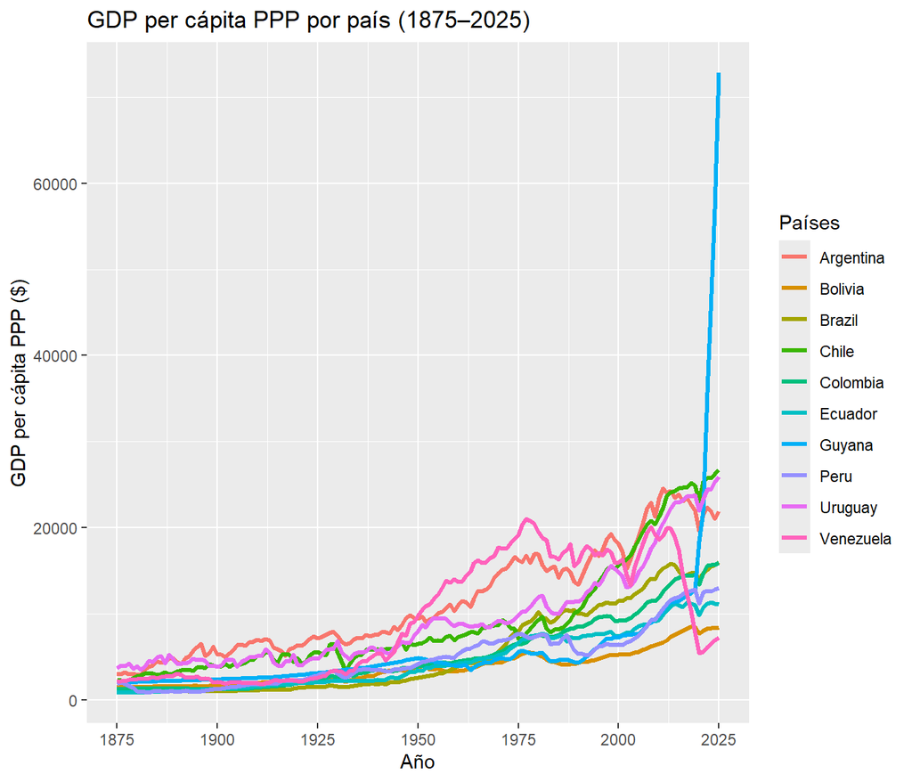

- La tendencia general es que todos los países de Suramérica han aumentado su GDP per cápita PPP.
- Dos países son notables:
- Venezuela en terminos de GDP per cápita PPP fué entre los años 1950 y finales de la década de 1990 el país con mayor poder adquisitivo. Seguido por una grave crisis económica a inicios de la década del 2010.
- Guyana ha sido históricamente un país con un bajo GDP Per cápita PPP, pero en 2015 se descubrieron grandes pozos petroleros en sus costas. En el año 2019 empezó la explotación lo que ha aumentado su GDP per cápita PPP de 12800$ en ese año hasta 72800$ en el 2025 y se espera que continue este crecimiento económico.

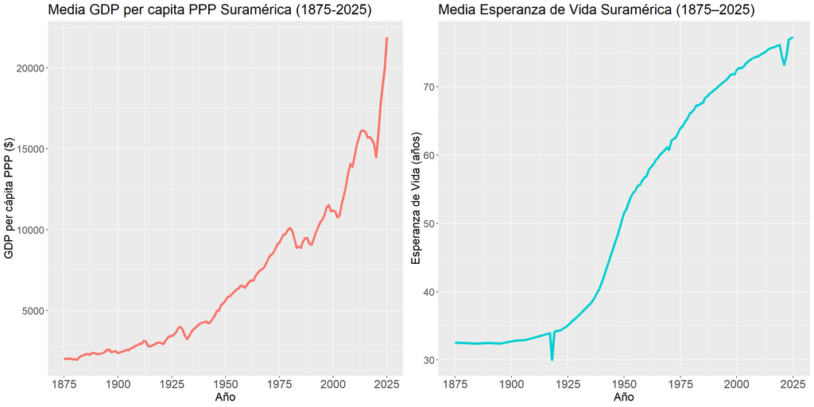